# Simulation for Significance of splitting (Jan. 2014)

Based on Jamie's notes [go to pdf](https://www.dropbox.com/s/jtw5z4uyrxj5rcg/Notes%202012-12-21.pdf)

## Setup

### Model

Two continuous latent variables (\( \eta \) and \( \xi \) ) are created with **N** cases, sharing a correlation equal to \( \rho \). A measure \( x \) of \( \xi \) is created with reliability \( rel \), and then is dichotomized accordingly to \( p \) \( 1-p \) into \( c \). The correlations \( r_pe=r(\eta,x) \) and \( r_pb=r(\eta,c) \) are computed, their p-value and significance (at .05) is recorded.

### Design

*N*={20, 40, 60, 80, 100, 120, 140, 160, 180, 200}  
*rho*={0}  
*rel*={0.3, 0.4, 0.5, 0.6, 0.7, 0.8, 0.9}

each combination of *N* and *rho* is repeated 100 times.

#### Proportions of samples where both correlations are significant (*both*), only the .biserial (*Split*), and only the Pearson (*continuos*) by reliability

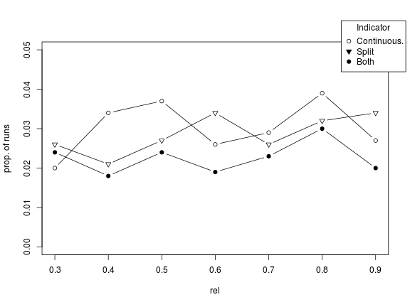

#### Proportion of significant results by N broken down by indicator type

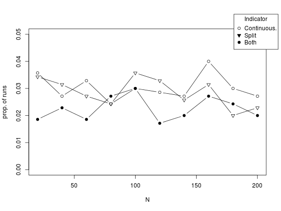

#### Mean abs distance between Pearson correlation and \( \rho \) results by reliability broken down by indicator significance

*in this case mean distance=effect size in terms of r*

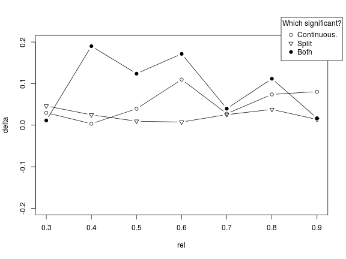

#### Mean abs distance between .biserial correlation and \( \rho \) results by reliability broken down by indicator significance

*in this case mean distance=effect size in terms of r*

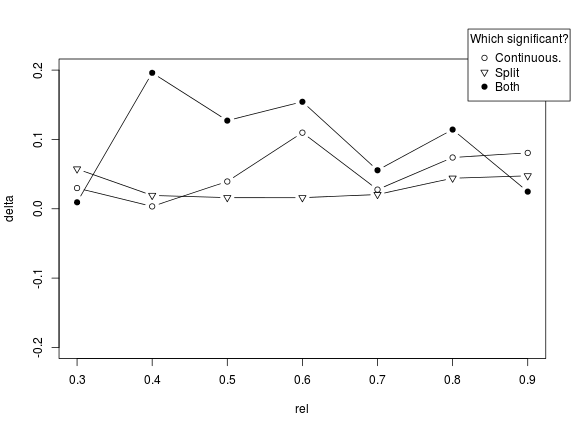

############## not null hypothesis #############

### Design

*N*={20, 40, 60, 80, 100, 120, 140, 160, 180, 200}  
*rho*={0.5}  
*rel*={0.3, 0.4, 0.5, 0.6, 0.7, 0.8, 0.9}

each combination of *N* and *rho* is repeated 100 times.

#### Proportions of samples where both correlations are significant (*both*), only the .biserial (*Split*), and only the Pearson (*continuos*) by reliability

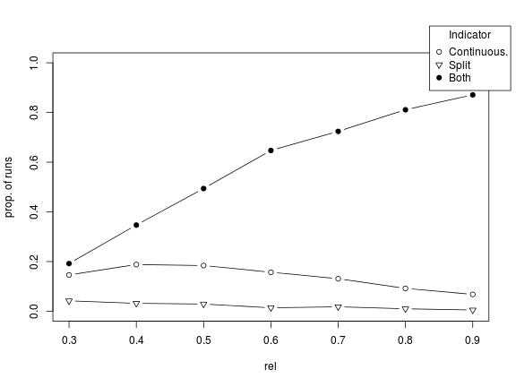

#### Proportion of significant results by N broken down by which indicator is significant

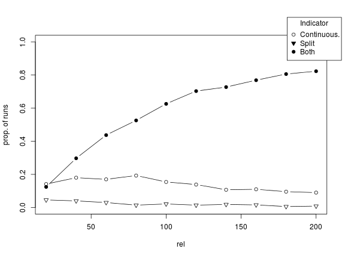

#### Mean abs distance between Pearson correlation and \( \rho \) results by reliability broken down by indicator significance

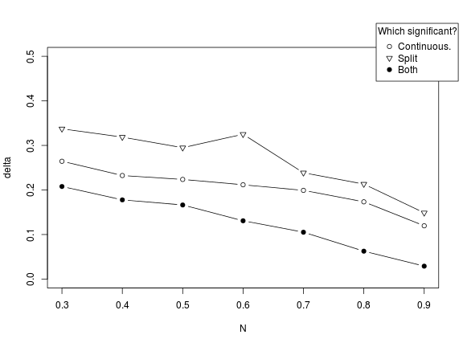

#### Mean abs distance between .biserial correlation and \( \rho \) results by reliability broken down by indicator significance

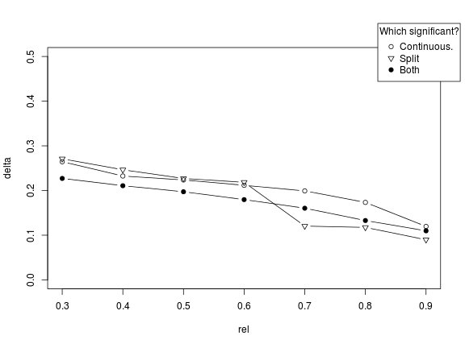

Proportions of samples when each of the correlation is significant

```
  Group.1 Group.2 Group.3    x
1       0       0     0.0 6430
2       1       0     0.0  212
3       0       1     0.0  200
4       1       1     0.0  158
5       0       0     0.5 1798
6       1       0     0.5  966
7       0       1     0.5  150
8       1       1     0.5 4086
```

```
  conti.sig split.sig rho freq     prop
1         0         0 0.0 6430 0.229643
2         1         0 0.0  212 0.007571
3         0         1 0.0  200 0.007143
4         1         1 0.0  158 0.005643
5         0         0 0.5 1798 0.064214
6         1         0 0.5  966 0.034500
7         0         1 0.5  150 0.005357
8         1         1 0.5 4086 0.145929
```

```
  conti.sig split.sig rho freq     prop
2         1         0   0  212 0.007571
4         1         1   0  158 0.005643
```

```
  conti.sig split.sig rho freq   prop
6         1         0 0.5  966 0.0345
8         1         1 0.5 4086 0.1459
```